# barthakur_rishee-lab05

### Machine Learning : Image recognition using neural network (MLP & CNN)

### Rishee Barthakur

In this project we are doing image classification using tensorflow(keras). We have a dataset where we have diffferent images of airplane, automobile, bird,cat, deer, dog , frog, horse, ship and truck. The pictures are in RGB color, each color has a dimension of 32 X 32 X 3 stored in X and the Y value here contain the lables in the from of numbers corrosponding to the class_name array. Our main task is to porform MLP (Multilayer Perceptron) and CNN (Convolutional neural network) and compare their performance.  
**Our majot tasks:**

##### PART 1

1. Load the data
2. Split the data train and test set.
3. From train set split the data into train and validation set.
4. Show images form train, validation and test set.
5. Make MLP model
6. Hyperparameter tuning of the model and save the model using directory
7. Test the model in test set by calling the model if it exists on the dir after training it for 1 epoch.
8. Create confusion matrix and f1 score of the model

##### PART 2

1. Make a CNN model for the same train, test and validation set
2. Perform hyperparameter tuning of the model and save the model using directory
3. Test the model using test set by calling the model if it exists on the dir after training it for 1 epoch.
4. Create confusion matrix and f1 score of the model
5. Compare the result of both the model MLP and CNN

#### Importing the required libraries

```python
import os
import sys
sys.path.append(os.getcwd())
import tensorflow as tf
from tensorflow import keras
import matplotlib.pyplot as plt
import matplotlib.image as mpimg
from numpy import random
from scipy.stats import reciprocal
from keras.wrappers.scikit_learn import KerasClassifier
from tensorflow.keras import layers
from tensorflow.keras import initializers
#ALL THE LIBRATIES ARE IMPORTED HERE
#Some additional libraries are also includes which we might not use in this Project
import pandas as pd
import numpy as np
import seaborn as sns
import seaborn as sns; sns.set_theme(color_codes=True)
from sklearn.model_selection import train_test_split
from sklearn.metrics import confusion_matrix,plot_confusion_matrix,precision_score,accuracy_score,classification_report,f1_score
#REMOVE WARNINGS
import warnings
warnings.filterwarnings('ignore')
```

### Loading the data

Loading the data from data_loader and creating X_train,y_train and x_test and y_test. The class_name contains the lables of the images in the form of an array.

```python
from data_loader import DataLoader
# According to the CIFAR-10 website, the training set is split into five batches
# stored in fives files. Each colour image has dimensions equal to 32 x 32 x 3. There
# are 10 classes.
image_width, image_height, image_Nchannels = 32, 32, 3
class_names = ['airplane', 'automobile', 'bird', 'cat', 'deer', 'dog', 'frog', 'horse', 'ship', 'truck']

# The default values of all the arguments of the load_batch function have been
# set for the CIFAR-10 dataset.
X_train, y_train = DataLoader.load_batch('data_batch')
X_test, y_test = DataLoader.load_batch('test_batch', Nbatches=1)
print('X_test.shape =', X_test.shape, 'data type:', X_test.dtype)
print('y_test.shape =', y_test.shape, 'data type:', y_test.dtype)
```

```
X_test.shape = (10000, 32, 32, 3) data type: float32
y_test.shape = (10000,) data type: uint8
```

#### Train validation split

The validation set has been created from the tarin set by taking 20% data.

```python
X_train, X_valid = train_test_split(X_train,test_size=0.20, random_state=42)
y_train ,y_valid =  train_test_split(y_train,test_size=0.20, random_state=42)

print('X_train.shape =', X_train.shape, 'data type:', X_test.dtype)
print('X_valid.shape =', X_valid.shape, 'data type:', y_test.dtype)
print('y_train.shape =', y_train.shape, 'data type:', X_test.dtype)
print('y_valid.shape =', y_valid.shape, 'data type:', y_test.dtype)
```

```
X_train.shape = (40000, 32, 32, 3) data type: float32
X_valid.shape = (10000, 32, 32, 3) data type: uint8
y_train.shape = (40000,) data type: float32
y_valid.shape = (10000,) data type: uint8
```

#### Showing Images

Creating a function to show the images from the train, validation and the test set.  
x and y are the parameters for the independent and dependent variables. We are showing total 20 images which containes 4 rows(num_row) and 5 columns (num_col) which will be passed in the subplots() to generate 20 images.

> **How to show random images?**  
> We are showing random images everytime we run the loop. In order to select random images we have used **random.randint(31)** which will generate random numbers everytime between 0-31. Because the len() of height and width is 32 so range(0,31) will consider 32 values in python. Then the randim number has been passed as in index in X[index] and y[index] which shows us the image with correct lables.

```python
def showImg(x,y):
    #x is for independent variables X_train
    #y is for dependent variables Y_train
    num_row = 4
    num_col = 5
    # plot images
    fig, axes = plt.subplots(num_row, num_col, figsize=(10,5))
    for i in range(20):
        ax = axes[i//num_col, i%num_col]
        #FOR RANDOM VALUES
        index = random.randint(31)
        ax.imshow((x[index]),cmap="binary", interpolation = "hamming")
        ax.set_axis_off()
        ax.set_title((class_names[y[index]]))
    plt.tight_layout()
    plt.show()
```

Calling the function 3 times for train, validation and test set

```
================Train===================
```

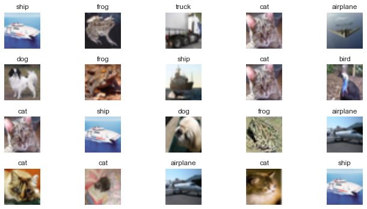

```
=============Validation=================
```

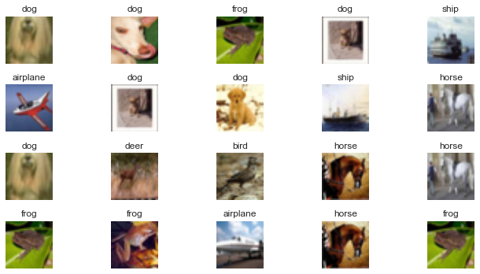

```
=================Test===================
```

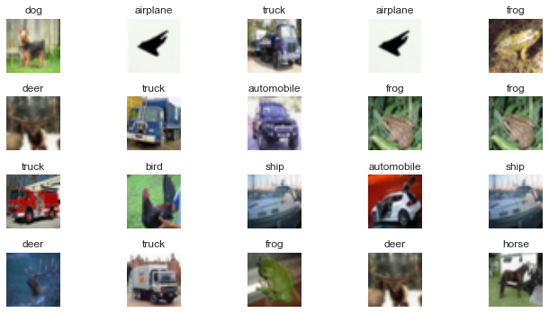

```python
print("================Train===================")
showImg(X_train,y_train)
print("=============Validation=================")
showImg(X_valid,y_valid)
print("=================Test===================")
showImg(X_test,y_test)
```

##### MLP

Creating MLP model with Sequential(), this function will make the model run in a sequence manner conrrospondin to all the layers from to to bottom. The Flatten layer will create 1D array from the input_shape=[32,32,3].  
**Dropout:** It can be added in each layer of the network which helps in preventing overfitting of the model by stopping the complex co-adaptations on the training data.  
**Dense:** This is the hidden layer. We have total 3 Dense layers in this network with 300, 100 and 10 neurons in each layers respectively. This layer hyperparameters such as activation function, kernel_initializer and many more but we are only considering 2 hyperparameters with the number of neurons.  
**activation:** activation function in hidden layer is used to define the transformation of weighted sum from input layer to output layer. We have used **relu** as an activation function so basically **relu(rectified linear activation function)** is used to transform the all negative inputs to 0 in the output layer and for positive input it will remain positive. It is a linear function and it performs well compared to other activation functions. **softmax** has been used in the last layer because softmax is responsible for the classification  
**kernel_initializer:** This is a regularization method whihc is used to avoid the overfitting of the model by initializing the weights and lecun_normal draws samples from a truncated normal distribution.  
**model.summary():** It is used for showing the architecture of the model.  
**model.compile():** sparse_categorical_crossentropy will show the loss on both the train and the validation and matrics=["accuracy"] will show the accuracy of both sets and we have used SDG as an optimer which is randomly select datapoints while running the algorithm .  
**CODE HAS BEEN COMMENTED OUT AFTER EXPERIMENTATION BECAUSE WE SAVED THE MODEL**

```python
# model = keras.models.Sequential([
#     keras.layers.Flatten(input_shape=[32, 32, 3]),
#     keras.layers.Dropout(rate=0.1),
#     keras.layers.Dense(300, activation="relu", kernel_initializer="lecun_normal"),
#     keras.layers.Dropout(rate=0.2),
#     keras.layers.Dense(100, activation="relu", kernel_initializer="lecun_normal"),
#     keras.layers.Dropout(rate=0.2),
#     keras.layers.Dense(10, activation="softmax")
# ])
# print("===============Architecture of MLP===================")
# model.summary()
# model.compile(loss="sparse_categorical_crossentropy", optimizer="sgd", metrics=["accuracy"])

# history = model.fit(X_train, y_train, epochs=100, validation_data=(X_valid, y_valid))
```

> we can see an overfitting in our model because the accuracy has a high variance in the train set compared to the validation set. However the vaule will differ everytime with a minimal chance as we are using SDG.(By 2-3 %)  
> Trainset Accuracy : 60.85%  
> Validation set Accuracy : 55.08%  
> The accuracy may increase or decrease by 2-3% as we are using SGD as an optimizer.

### Showing results

Shwoing results using graph by putting accuracy and loss in train set and the validation set.  
**CODE HAS BEEN COMMENTED OUT AFTER EXPERIMENTATION, WE SAVED THE MODEL**

```python
# pd.DataFrame(history.history).plot(figsize=(8, 5))
# plt.grid(True)
# plt.gca().set_ylim(0, 2)
# #save_fig("keras_learning_curves_plot")
# plt.show()
```

### Hyperparameter tuning

We have **reduced the number of neurons** because by doing so our weight values will lesser compared to the previous model which will avoid overfitting of the model.We kept the dropout constant which **0.2** for all the layers and we are using **he_normal** in the kernel_initializer which performs better than the lecun_normal withn ReLU activation function because it finds good variance from distribution.  
**CODE HAS BEEN COMMENTED OUT AFTER EXPERIMENTATION, WE SAVED THE MODEL**

```python
# def myModel_MLP():
#   model_MLP = keras.models.Sequential([
#       keras.layers.Flatten(input_shape=[32, 32, 3]),
#       keras.layers.Dropout(rate=0.2),
#       keras.layers.Dense(200, activation="relu", kernel_initializer="he_normal"),
#       keras.layers.Dropout(rate=0.2),
#       keras.layers.Dense(50, activation="relu", kernel_initializer="he_normal"),
#       keras.layers.Dropout(rate=0.2),
#       keras.layers.Dense(10, activation="softmax")
#   ])
#   model_MLP.summary()
#   model_MLP.compile(loss="sparse_categorical_crossentropy", optimizer="sgd", metrics=["accuracy"])
#   return model_MLP
# #STORING THE MODEL INTO A VARIABLE
# MLP_model = myModel_MLP()
# history = MLP_model.fit(X_train, y_train, epochs=100, validation_data=(X_valid, y_valid))
```

> **Results**  
> **The accuracy**  
> Train set : 0.51  
> validation set : 0.52  
> **Loss**  
> Train set : 1.33  
> validation set : 1.33  
> **The values can differ by 2-3% (increase or decrease) as we are using SGD optimizer because each time it will select sample data points randomly.**

### Showing results

Same process has been followed to generate the graph as the previous model. It is just that this time we have a tuned model.  
**CODE HAS BEEN COMMENTED OUT AFTER EXPERIMENTATION, WE SAVED THE MODEL**

```python
# pd.DataFrame(history.history).plot(figsize=(8, 5))
# plt.grid(True)
# plt.gca().set_ylim(0, 2.5)
# #save_fig("keras_learning_curves_plot")
# plt.show()
```

### Early stopping

We have used early stopping to take the best epochs from our model. Early stopping will only consider the those epochs which are not overfitted considering the best weights **restore_best_weights=True**, patience is used to stop the training for the epochs with no improvement so we are considering patience=10 which indicates 10 epochs with no improvement and the training will stop.  
**CODE HAS BEEN COMMENTED OUT AFTER EXPERIMENTATION, WE SAVED THE MODEL**

```python
# #USED EARLY STOPPING
# early_stopping_cb = keras.callbacks.EarlyStopping(patience=10, restore_best_weights=True)
# history = MLP_model.fit(X_train, y_train, epochs=100, validation_data=(X_valid, y_valid),callbacks=[early_stopping_cb])
```

> **Results after early stopping**  
> **The accuracy**  
> Train set : 0.52  
> validation set : 0.52  
> **Loss**  
> Train set : 1.31  
> validation set : 1.31  
> **The values can differ by 2-3% (increase or decrease) as we are using SGD optimizer because each time it will select sample data points randomly.**

### Saving the MLP

We are saving the model in a directory called barthakur_rishee-MLP  
**CODE HAS BEEN COMMENTED OUT AFTER EXPERIMENTATION, WE SAVED THE MODEL**

```python
#MLP_model.save("barthakur_rishee-MLP")
```

### Checking directory

If the directory exits we train the model for 1 epoch otherwise we will create a new model and train it for 100 epochs.  
Also here we will show the **Architecture** of the model.  
If the directory is not present then uncomment the above code for the model.  
**Architecture** : Architecture has been explained in model building and the Hyperparameter tuning section.

```python
def callingModel():
  if os.path.isdir("barthakur_rishee-MLP"):
    MLP_model = keras.models.load_model("barthakur_rishee-MLP")
    print("================Architeture=================")
    MLP_model.summary()
    MLP_model.fit(X_train,y_train, epochs=1, validation_data=(X_valid,y_valid))
    return MLP_model

  else:
    print("===============Architecture==================")
    MLP_model.summary()
    MLP_model = myModel_MLP()
    history = MLP_model.fit(X_train, y_train, epochs=100, validation_data=(X_valid, y_valid))
    MLP_model.fit(X_train,y_train, epochs=100, validation_data=(X_valid,y_valid))
    return MLP_model

MLP_model = callingModel()
```

```
================Architeture=================
Model: "sequential_1"
_________________________________________________________________
Layer (type)                 Output Shape              Param #
=================================================================
flatten_1 (Flatten)          (None, 3072)              0
_________________________________________________________________
dropout_3 (Dropout)          (None, 3072)              0
_________________________________________________________________
dense_3 (Dense)              (None, 200)               614600
_________________________________________________________________
dropout_4 (Dropout)          (None, 200)               0
_________________________________________________________________
dense_4 (Dense)              (None, 50)                10050
_________________________________________________________________
dropout_5 (Dropout)          (None, 50)                0
_________________________________________________________________
dense_5 (Dense)              (None, 10)                510
=================================================================
Total params: 625,160
Trainable params: 625,160
Non-trainable params: 0
_________________________________________________________________
```

### Testing the model

Now I will use X_test and y_test to evaluaate the test result.

```python
MLP_model.evaluate(X_test, y_test)
```

```
[1.3210433721542358, 0.5260000228881836]
```

### Confusion Matrix and F1 score

```python
y_pred = np.argmax(MLP_model.predict(X_test), axis=-1)
print("Predicted values : : ",np.array(class_names)[y_pred])
print("F1 score MLP : ",f1_score(y_test,y_pred,average="macro"))
#CONFUSION MATRIX
a = confusion_matrix(y_test, y_pred)
a
```

```
Predicted values : :  ['cat' 'ship' 'ship' ... 'cat' 'dog' 'horse']
F1 score MLP :  0.5221381658303985
```

```
array([[569,  31,  34,  42,  36,  19,  33,  33, 151,  52],
       [ 35, 665,   4,  21,   6,  21,  20,  18,  70, 140],
       [ 71,  22, 283, 123, 169,  86, 136,  68,  21,  21],
       [ 21,  14,  44, 368,  46, 235, 153,  65,  23,  31],
       [ 46,  10, 104,  75, 433,  55, 145,  96,  24,  12],
       [ 11,   7,  60, 225,  61, 430,  93,  64,  27,  22],
       [  3,  16,  36,  89,  89,  43, 675,  23,  12,  14],
       [ 36,  10,  21,  67,  73, 108,  46, 591,  13,  35],
       [ 98,  69,   9,  26,  16,  32,   8,   9, 677,  56],
       [ 33, 186,   4,  51,   9,  20,  26,  48,  54, 569]], dtype=int64)
```

> **F1 score : 0.52**  
> As the the accuracy of the model is not too high because of which we have more False positive and False negetive values.

### Showing images

Here we are showing the predicted images from using oou model.

```
========REAL VALUE=======
```

```
======Predicted value=======
```

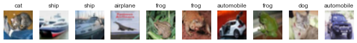

```python
def showImgPred(x,y):
    #x is for independent variables X_train
    #y is for dependent variables Y_train

    num_row = 1
    num_col = 10
    # plot images
    fig, axes = plt.subplots(num_row, num_col, figsize=(10,5))
    for i in range(10):
        ax = axes[i%num_col]
        #index = random.randint(31)
        ax.imshow((x[i]),cmap="binary", interpolation = "hamming")
        ax.set_axis_off()
        ax.set_title((class_names[y[i]]))
    plt.tight_layout()
    plt.show()
print("========REAL VALUE=======")
showImgPred(X_test,y_test)
print("======Predicted value=======")
showImgPred(X_test,y_pred)
```

[output not shown]

> We can see in the predicted images some wrongly predicted images.  
> **NOTE**  
> We might not observe wrongly predicted image sometime because of SGD. Each time it selects the data points randomly, may be the data points which we haved passed as an argument could be predicted correctly by the optimizer.  
> **In the second last picture the model predicted cat as a dog.**

**PART 2**  
In the part 2 of the project we will perform CNN (convolutional neural network ) which is slightly differnt than the MLP and it is considered as better performer for image recognition compared to MLP. CNN contains convolutional layer, pooling layer and fully connected layer. We can increase or decrease the number of layers.  
**Conv2d :** This is the convolution layer it takes the pixels from an input image and helps in recognizing the patterns, we have passed filters=64 which represents 64 nodes, kernal_size=7 represents the widthxheight of the filter, **activation="relu"** is used to make the negative output as 0., **padding="SAME"** is used to provide enough pixels in the covolutional layer to train our model and the input_shape consists of our input dimension. **softmax** has been used in the last layer for the classification.  
**MaxPolling2D :** This is the pooling layer it shrinks the image by only considering the maximum values from the pixel array and convert it into 2D array.**MaxPooling2D(2)** indicates pooling size referes to 2 X 2 kernel.  
**Flatten():** Then we flatten the model as the way we have done in MLP which will a 1D array.  
**Dense():** We have used 2 Dense layers which are fully connected layers as MLP with relu as an activation function and the last layer consists of softman for the classification of the images.  
**BatchNormalization() :** It is used for standardizing the inputs to a layer for each mini-batch to another layer.  
**Optimizer :** We have used SGD optimizer to train our model.

**CODE HAS BEEN COMMENTED OUT AFTER EXPERIMENTATION, WE SAVED THE MODEL**

```python
# model2 = keras.models.Sequential([
#     keras.layers.Conv2D(filters=64, kernel_size=7, activation="relu", padding="same",input_shape=[32, 32, 3]),
#     keras.layers.MaxPooling2D(2),
#     keras.layers.Conv2D(filters=64, kernel_size=3, activation="relu", padding="same"),
#     keras.layers.MaxPooling2D(2),
#     keras.layers.Flatten(),
#     keras.layers.Dense(128, activation="relu"),
#     keras.layers.BatchNormalization(),
#     keras.layers.Dense(64, activation="relu"),
#     keras.layers.BatchNormalization(),
#     keras.layers.Dense(10, activation="softmax")
# ])
# model2.summary()
# model2.compile(loss="sparse_categorical_crossentropy",optimizer="sgd" , metrics=["accuracy"])
# history = model2.fit(X_train, y_train, epochs=100,validation_data=(X_valid, y_valid))
```

> **Results**  
> **The accuracy**  
> Train set : 0.98 (overfitting)  
> validation set : 0.67  
> **Loss**  
> Train set : 0.02  
> validation set : 2.33 (overfitting)  
> **The values can differ by 2-3% (increase or decrease) as we are using SGD optimizer because each time it will select sample data points randomly.**

### Showing results

We have used the same graphs which we have used in MLP, just the model is CNN.  
**CODE HAS BEEN COMMENTED OUT AFTER EXPERIMENTATION, WE SAVED THE MODEL**

```python
# pd.DataFrame(history.history).plot(figsize=(8, 5))
# plt.grid(True)
# plt.gca().set_ylim(0, 4)
# #save_fig("keras_learning_curves_plot")
# plt.show()
```

### Evaluate test set

```python
# model2.evaluate(X_test, y_test)
```

> Our Train accuracy is above **0.98** and the test accuracy is above **0.66** which clearly shows an **overfitting** of the model.

### Hyperparameter Tuning - CNN

```python
# def myModel_CNN():
#   model_CNN = keras.models.Sequential([
#     keras.layers.Conv2D(filters=50, kernel_size=7, activation="relu", padding="same",input_shape=[32, 32, 3]),
#     keras.layers.MaxPooling2D(2),
#     keras.layers.Dropout(rate=0.3),
#     keras.layers.Conv2D(filters=25, kernel_size=5, activation="relu", padding="same",kernel_initializer="he_normal"),
#     keras.layers.MaxPooling2D(2),
#     keras.layers.Dropout(rate=0.2),
#     keras.layers.Conv2D(filters=25, kernel_size=5, activation="relu", padding="same",kernel_initializer="he_normal"),
#     keras.layers.MaxPooling2D(2),
#     keras.layers.Dropout(rate=0.1),
#     keras.layers.Flatten(),
#     keras.layers.Dense(20, activation="relu"),
#     keras.layers.BatchNormalization(),
#     keras.layers.Dense(10, activation="softmax")
#   ])
#   model_CNN.summary()
#   model_CNN.compile(loss="sparse_categorical_crossentropy", optimizer="sgd", metrics=["accuracy"])
#   return model_CNN
# #STORING THE MODEL INTO A VARIABLE
# CNN_model = myModel_CNN()
# history = CNN_model.fit(X_train, y_train, epochs=100, validation_data=(X_valid, y_valid))
```

### Showing results

Same process has been used to generate the graph just trained the model with tuned hyperparameters.  
**CODE HAS BEEN COMMENTED OUT AFTER EXPERIMENTATION, WE SAVED THE MODEL**

```python
# pd.DataFrame(history.history).plot(figsize=(8, 5))
# plt.grid(True)
# plt.gca().set_ylim(0, 2)
# #save_fig("keras_learning_curves_plot")
# plt.show()
```

### Early stopping

We have used early stopping to take the best epochs from our model which will further more remove the epochs with no improvement. Early stopping will only consider the those epochs which are not overfitted considering the best weights **restore_best_weights=True**, patience is used to stop the training for the epochs with no improvement so we are considering patience=10 which indicates 10 epochs with no improvement and the training will stop. SAME AS MLP.  
**CODE HAS BEEN COMMENTED OUT AFTER EXPERIMENTATION, WE SAVED THE MODEL**

```python
# #USED EARLY STOPPING
# early_stopping_cb = keras.callbacks.EarlyStopping(patience=10, restore_best_weights=True)
# history = CNN_model.fit(X_train, y_train, epochs=100, validation_data=(X_valid, y_valid),callbacks=[early_stopping_cb])
```

> **Results**  
> **The accuracy**  
> Train set : 0.77  
> validation set : 0.76  
> **Loss**  
> Train set : 0.65  
> validation set : 76  
> **The results may vary by 2-3% dependening on the epochs**

We are saving the model in a directory called barthakur_rishee-CNN

```python
# CNN_model.save("barthakur_rishee-CNN")
```

### Checking directory

If the directory exits we train the model for 1 epoch otherwise we will create a new model and train it for 100 epochs.  
Also here we will show the **Architecture** of the model.

**Architecture** : Architecture has been explained in model building and the Hyperparameter tuning section.

```python
def callingModel():
  if os.path.isdir("barthakur_rishee-CNN"):
    CNN_model = keras.models.load_model("barthakur_rishee-CNN")
    print("Architeture CNN")
    CNN_model.summary()
    CNN_model.fit(X_train,y_train, epochs=1, validation_data=(X_valid,y_valid))
    return CNN_model

  else:
    print("Architecture CNN")
    CNN_model.summary()
    CNN_model.fit(X_train,y_train, epochs=100, validation_data=(X_valid,y_valid))
    CNN_model.evaluate(X_test, y_test)
    return CNN_model
CNN_model = callingModel()
```

```
Architeture CNN
Model: "sequential_3"
_________________________________________________________________
Layer (type)                 Output Shape              Param #
=================================================================
conv2d_2 (Conv2D)            (None, 32, 32, 50)        7400
_________________________________________________________________
max_pooling2d_2 (MaxPooling2 (None, 16, 16, 50)        0
_________________________________________________________________
dropout_6 (Dropout)          (None, 16, 16, 50)        0
_________________________________________________________________
conv2d_3 (Conv2D)            (None, 16, 16, 25)        31275
_________________________________________________________________
max_pooling2d_3 (MaxPooling2 (None, 8, 8, 25)          0
_________________________________________________________________
dropout_7 (Dropout)          (None, 8, 8, 25)          0
_________________________________________________________________
conv2d_4 (Conv2D)            (None, 8, 8, 25)          15650
_________________________________________________________________
max_pooling2d_4 (MaxPooling2 (None, 4, 4, 25)          0
_________________________________________________________________
dropout_8 (Dropout)          (None, 4, 4, 25)          0
_________________________________________________________________
flatten_3 (Flatten)          (None, 400)               0
_________________________________________________________________
dense_9 (Dense)              (None, 20)                8020
_________________________________________________________________
batch_normalization_2 (Batch (None, 20)                80
_________________________________________________________________
dense_10 (Dense)             (None, 10)                210
=================================================================
Total params: 62,635
Trainable params: 62,595
Non-trainable params: 40
_________________________________________________________________
```

### Evaluating on test set

```python
CNN_model.evaluate(X_test, y_test)
```

```
[0.7148920893669128, 0.7506999969482422]
```

**Values might vary because everything is randomly selected by algorithm(hyperparameters).**

### Prediction

Prediction using CNN model, also herec we are showinf the confusion matrix and the F1 score.

```python
y_pred = np.argmax(CNN_model.predict(X_test), axis=-1)
print("Predicted values : : ",np.array(class_names)[y_pred])
print("F1 score MLP : ",f1_score(y_test,y_pred,average="macro"))
a = confusion_matrix(y_test, y_pred)
a
```

```
Predicted values : :  ['dog' 'ship' 'ship' ... 'dog' 'deer' 'horse']
F1 score MLP :  0.7480452494708929
```

```
array([[818,  13,  30,  14,  15,   3,  18,  12,  48,  29],
       [ 12, 891,   4,   4,   6,   5,  13,   1,  19,  45],
       [ 84,   1, 565,  35,  76,  82, 122,  20,   8,   7],
       [ 21,   7,  44, 497,  53, 193, 151,  20,   8,   6],
       [ 20,   3,  40,  32, 717,  32, 105,  38,  10,   3],
       [ 11,   3,  36, 118,  35, 697,  64,  29,   4,   3],
       [  7,   1,  22,  18,  12,  18, 912,   3,   5,   2],
       [ 16,   7,  32,  27,  63,  64,  22, 764,   1,   4],
       [ 62,  29,  10,  13,   7,   2,  14,   4, 844,  15],
       [ 27, 102,   4,  10,   3,   6,  15,   8,  23, 802]], dtype=int64)
```

> F1 score is 0.74 which is much better than the MLP

### Showing predicted image

The function which we have created for MLP has been called here with the new y_pred values predicted by CNN passing as a parameter.

```python
print("========REAL VALUE=======")
showImgPred(X_test,y_test)
print("======Predicted value=======")
showImgPred(X_test,y_pred)
```

[output not shown]

```
========REAL VALUE=======
```

```
======Predicted value=======
```

> More than 74% of the images will be predicted correctly.